# Rep_data_PeerAssessment1

Cerys Williams

2025-12-16

### Upload the dataset

```r
library(tidyverse)
activity <- read_csv("activity.csv")
```

### Set echo = TRUE as global default to ensure it is always used in each code chunk.

```r
knitr::opts_chunk$set(echo = TRUE)
```

### What is the total number of steps taken in one day?

Step 1: Calculate the total number of steps take in one day.

```r
daily_steps_total <- activity %>%
  group_by(date) %>%
  summarise(sum_total_steps = sum(steps))
```

Step 2: Make a histogram of the total number of steps each day.

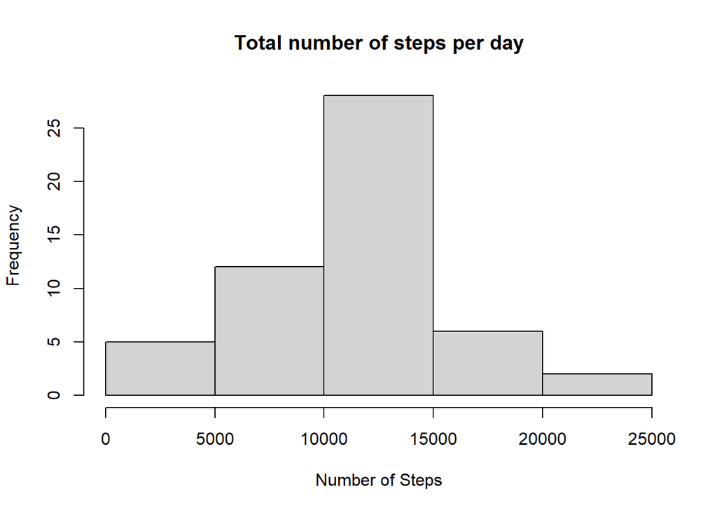

```r
hist(daily_steps_total$sum_total_steps,
     main = "Total number of steps per day",
     xlab = "Number of Steps",
     ylab = "Frequency",
     )
```

```r
daily_steps_mean_median <- daily_steps_total %>%
  group_by(date) %>%
  summarise(mean_total_steps = mean(sum_total_steps), median_total_steps = median(sum_total_steps))
```

### What is the average daily activity pattern?

Step 1: Create a time series plot of the 5-minute interval (x-axis) and the average number of steps taken, averaged across all days (y-axis). Ignoring the N/A in this case does not produce a valid response.

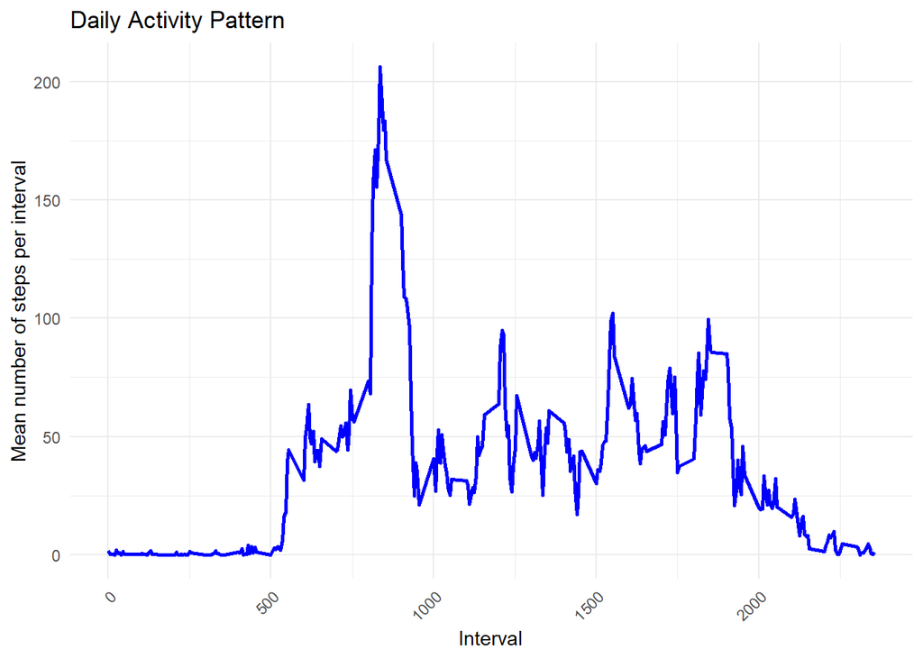

```r
interval_mean <- activity %>%
  group_by(interval) %>%
  summarise(interval_mean = mean(steps, na.rm = TRUE))

ggplot(interval_mean, aes(x = interval, y = interval_mean)) +
  geom_line(color = "blue", lwd = 1) +
  labs(title = "Daily Activity Pattern",
       x = "Interval",
       y = "Mean number of steps per interval") +
  theme_minimal() +
  theme(axis.text.x = element_text(angle = 45, hjust = 1))
```

```r
interval_max <- activity %>%
  group_by(interval) %>%
  summarise(max_steps = max(steps, na.rm = TRUE)) %>%
  arrange(desc(max_steps))

head(interval_max)
```

```
## # A tibble: 6 × 2
##   interval max_steps
##      <dbl>     <dbl>
## 1      615       806
## 2      900       802
## 3      550       794
## 4      720       789
## 5      835       786
## 6      925       785
```

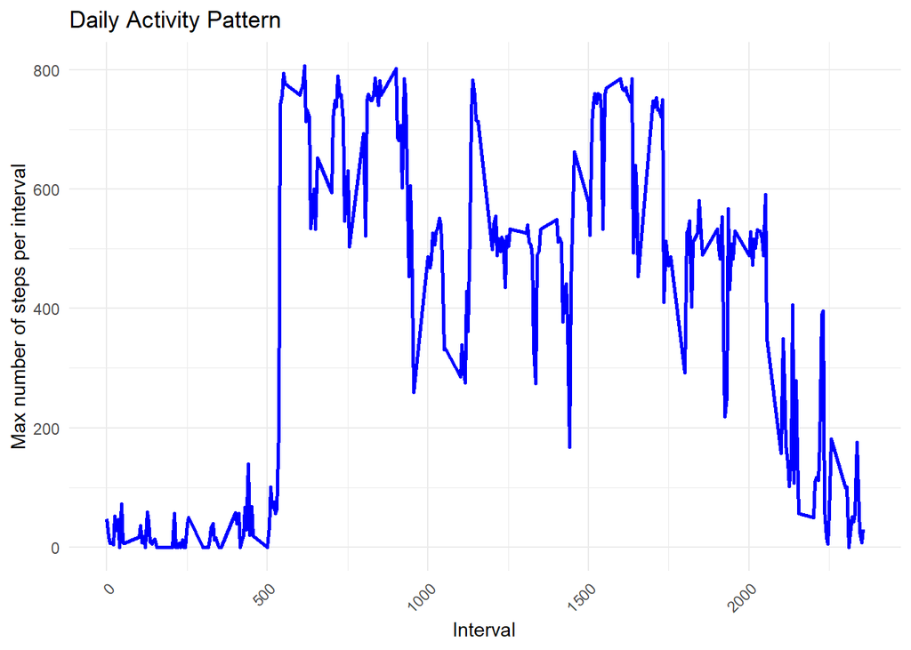

```r
ggplot(interval_max, aes(x = interval, y = max_steps)) +
  geom_line(color = "blue", lwd = 1) +
  labs(title = "Daily Activity Pattern",
       x = "Interval",
       y = "Max number of steps per interval") +
  theme_minimal() +
  theme(axis.text.x = element_text(angle = 45, hjust = 1))
```

### Imputing missing values

Calculate the total number of NA in the activity data set.

```r
colSums(is.na(activity))
```

```
##    steps     date interval
##     2304        0        0
```

A new dataset has been created where the mean for that 5-minute interval in the day has been used to fill in all of the missing values. The number of NA is is recalculated in the new dateset to make sure that none remain.

```r
activity_imputed <- activity %>%
  group_by(interval) %>%
  mutate(steps = ifelse(is.na(steps),
                        mean(steps, na.rm = TRUE),
                        steps))

colSums(is.na(activity_imputed))
```

```
##    steps     date interval
##        0        0        0
```

### Are there differences in activity patterns between weekdays and weekends?

Used the weekdays() function to create a variable containing the 2 levels Weekday and weekend.

```r
activity_imputed <- activity_imputed %>%
  mutate(date, weekdays(date)) %>%
  mutate(weekdays = case_when(`weekdays(date)` %in% c("Saturday", "Sunday") ~ "Weekend",TRUE ~ "Weekday"))
```

Calculated the mean number of steps per interval, averaged across all weekday days or weekend days. Use the data to create a panel plot containing time series plots of the 5-minute interval (x-axis) and the average number of steps taken, averaged across all weekday days or weekend days (y-axis) using ggplot2 and facet_wrap function.

```r
activity_imputed_averaged <- activity_imputed %>%
  group_by(interval, weekdays) %>%
  summarise(mean_steps = mean(steps))
```

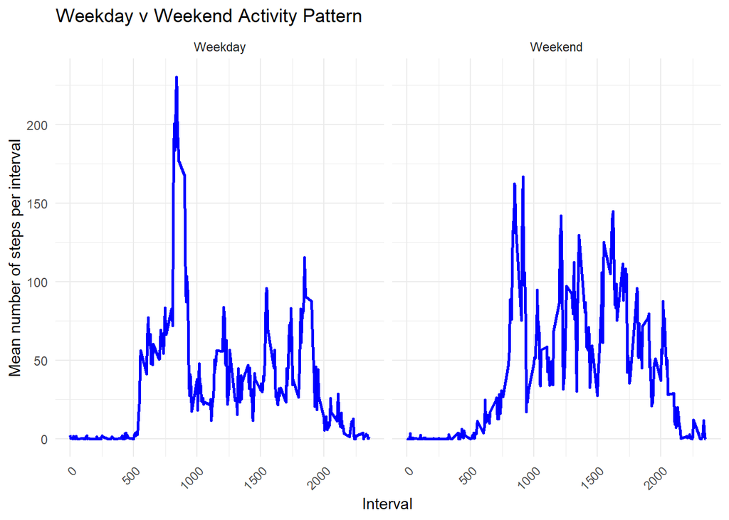

```r
ggplot(activity_imputed_averaged, aes(x = interval, y = mean_steps)) +
  geom_line(color = "blue", lwd = 1) +
  facet_wrap(~ weekdays) +
  labs(title = "Weekday v Weekend Activity Pattern",
       x = "Interval",
       y = "Mean number of steps per interval") +
  theme_minimal() +
  theme(axis.text.x = element_text(angle = 45, hjust = 1))
```